# LME Analysis of PNs

Conditional and marginal R<sup>2</sup> of model

| R2_conditional | R2_marginal |
| --- | --- |
| 0.85 | 0.71 |

$acc_phon

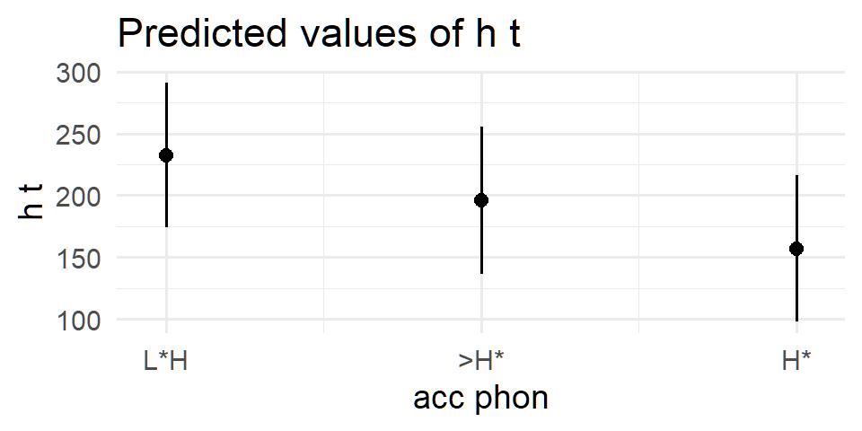

$ana_syls

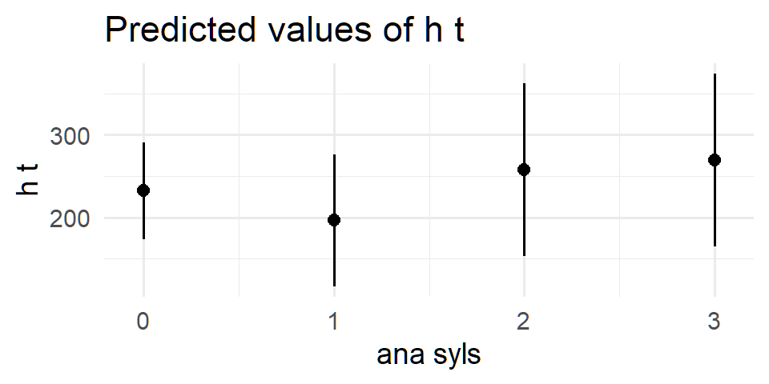

$foot_syls

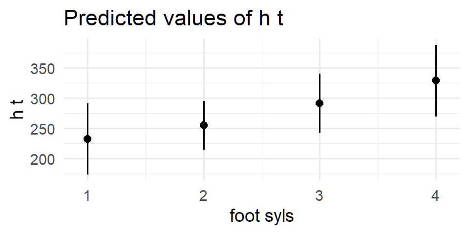

$wrd_end_syl

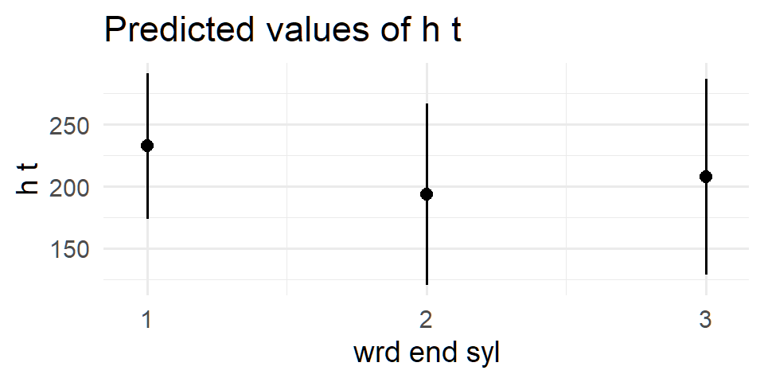

$pn_new_word

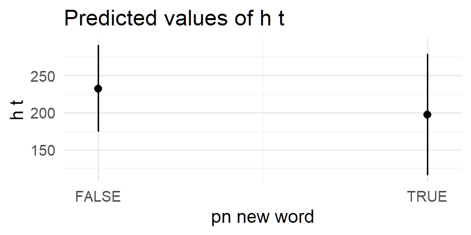

$gender

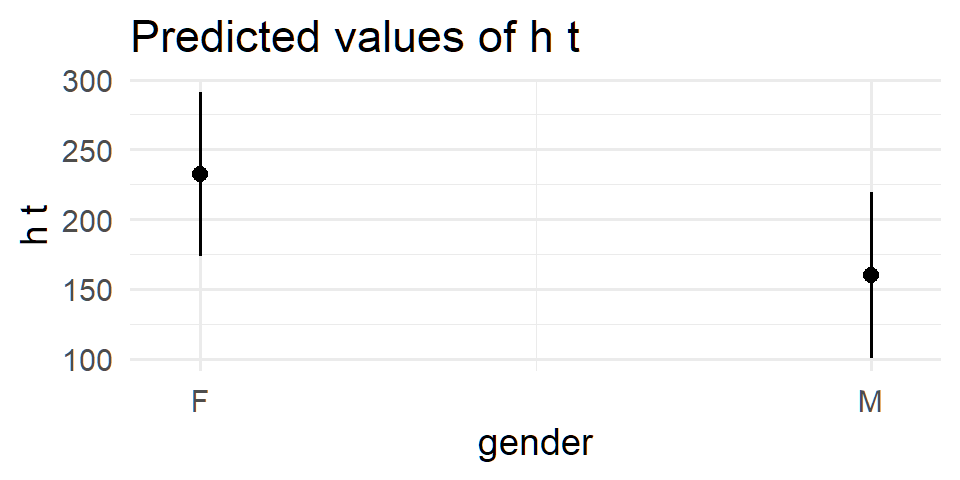

summary of model: h_t ~ acc_phon + ana_syls + foot_syls + wrd_end_syl + pn_new_word + gender + (1 | speaker) + (1 | ana_text) + (1 | nuc_pre_text)

| term | estimate | conf.low | conf.high | std.error | t.value | df | p.value |
| --- | --- | --- | --- | --- | --- | --- | --- |
| (Intercept) | 232.477 | 158.5926372 | 306.36139 | 29.928 | 7.768 | 5.79 | 3e-04 |
| acc_phon>H* | -36.573 | -48.4557079 | -24.69114 | 6.052 | -6.043 | 693.52 | 2.5e-09 |
| acc_phonH* | -75.388 | -84.7548424 | -66.02029 | 4.771 | -15.801 | 698.62 | 2.6e-48 |
| ana_syls1 | -35.829 | -113.7320297 | 42.07310 | 29.201 | -1.227 | 4.46 | 0.2807 |
| ana_syls2 | 25.502 | -91.2505718 | 142.25519 | 44.643 | 0.571 | 4.73 | 0.5939 |
| ana_syls3 | 37.128 | -79.6243431 | 153.87949 | 44.673 | 0.831 | 4.74 | 0.4457 |
| foot_syls2 | 22.669 | -62.2012847 | 107.53847 | 31.683 | 0.715 | 4.40 | 0.5104 |
| foot_syls3 | 58.768 | -33.7597923 | 151.29497 | 35.526 | 1.654 | 4.79 | 0.1615 |
| foot_syls4 | 96.536 | 0.1988763 | 192.87388 | 38.869 | 2.484 | 5.70 | 0.0497 |
| wrd_end_syl2 | -38.840 | -88.3316039 | 10.65248 | 22.317 | -1.740 | 10.36 | 0.1114 |
| wrd_end_syl3 | -24.768 | -81.9859189 | 32.45041 | 27.136 | -0.913 | 17.13 | 0.374 |
| pn_new_wordTRUE | -35.132 | -112.2342591 | 41.96968 | 30.069 | -1.168 | 5.04 | 0.2949 |
| genderM | -72.366 | -103.4478812 | -41.28423 | 13.765 | -5.257 | 9.11 | 5e-04 |

```
## h_t ~ acc_phon + ana_syls + foot_syls + wrd_end_syl + pn_new_word +
##     gender + (1 | speaker) + (1 | ana_text) + (1 | nuc_pre_text)
```

b0 for h_t ~ acc_phon + ana_syls + foot_syls + wrd_end_syl + pn_new_word + gender + (1 | speaker) + (1 | ana_text) + (1 | nuc_pre_text)

| intercept | estimate | conf.low | conf.high | std.error | t.value | df | p.value |
| --- | --- | --- | --- | --- | --- | --- | --- |
| acc_phonL*H | 232.5 | 158.6 | 306.4 | 29.928 | 7.768 | 5.79 | 2.9e-04 |
| acc_phon>H* | 195.9 | 122 | 269.8 | 30.402 | 6.444 | 6.17 | 5.9e-04 |
| acc_phonH* | 157.1 | 83.2 | 231 | 30.048 | 5.228 | 5.89 | 0.002 |
| ana_syls0 | 232.5 | 158.6 | 306.4 | 29.928 | 7.768 | 5.79 | 2.9e-04 |
| ana_syls1 | 196.6 | 93.4 | 299.9 | 40.638 | 4.839 | 5.20 | 0.004 |
| ana_syls2 | 258 | 123.3 | 392.7 | 53.184 | 4.851 | 5.26 | 0.004 |
| ana_syls3 | 269.6 | 134.9 | 404.3 | 53.208 | 5.067 | 5.27 | 0.003 |
| foot_syls1 | 232.5 | 158.6 | 306.4 | 29.928 | 7.768 | 5.79 | 2.9e-04 |
| foot_syls2 | 255.1 | 206.1 | 304.2 | 20.529 | 12.428 | 6.65 | 7.5e-06 |
| foot_syls3 | 291.2 | 231.7 | 350.7 | 25.243 | 11.538 | 7.11 | 7.3e-06 |
| foot_syls4 | 329 | 261.5 | 396.5 | 30.182 | 10.901 | 9.74 | 9.0e-07 |
| wrd_end_syl1 | 232.5 | 158.6 | 306.4 | 29.928 | 7.768 | 5.79 | 2.9e-04 |
| wrd_end_syl2 | 193.6 | 105.8 | 281.5 | 37.208 | 5.204 | 7.04 | 0.001 |
| wrd_end_syl3 | 207.7 | 116.3 | 299.1 | 40.225 | 5.164 | 8.76 | 6.5e-04 |

b1 for h_t ~ acc_phon + ana_syls + foot_syls + wrd_end_syl + pn_new_word + gender + (1 | speaker) + (1 | ana_text) + (1 | nuc_pre_text)

| intercept | slope | estimate | conf.low | conf.high | std.error | t.value | df | p.value |
| --- | --- | --- | --- | --- | --- | --- | --- | --- |
| acc_phonL*H | acc_phon>H* | -36.6 | -48.5 | -24.7 | 6.052 | -6.043 | 693.52 | 2.5e-09 |
| acc_phonL*H | acc_phonH* | -75.4 | -84.8 | -66 | 4.771 | -15.801 | 698.62 | 2.6e-48 |
| acc_phon>H* | acc_phonH* | -38.8 | -51.4 | -26.2 | 6.417 | -6.048 | 689.71 | 2.4e-09 |
| ana_syls0 | ana_syls1 | -35.8 | -113.7 | 42.1 | 29.201 | -1.227 | 4.46 | 0.281 |
| ana_syls0 | ana_syls2 | 25.5 | -91.3 | 142.3 | 44.643 | 0.571 | 4.73 | 0.594 |
| ana_syls0 | ana_syls3 | 37.1 | -79.6 | 153.9 | 44.673 | 0.831 | 4.74 | 0.446 |
| ana_syls1 | ana_syls2 | 61.3 | -25.9 | 148.6 | 33.771 | 1.816 | 4.92 | 0.13 |
| ana_syls1 | ana_syls3 | 73 | -14.3 | 160.2 | 33.811 | 2.158 | 4.93 | 0.084 |
| ana_syls2 | ana_syls3 | 11.6 | -689.6 | 712.8 | 12.128 | 0.959 | 0.62 | 0.579 |
| foot_syls1 | foot_syls2 | 22.7 | -62.2 | 107.5 | 31.683 | 0.715 | 4.40 | 0.51 |
| foot_syls1 | foot_syls3 | 58.8 | -33.8 | 151.3 | 35.526 | 1.654 | 4.79 | 0.162 |
| foot_syls1 | foot_syls4 | 96.5 | 0.199 | 192.9 | 38.869 | 2.484 | 5.70 | 0.05 |
| foot_syls2 | foot_syls3 | 36.1 | -34.7 | 106.9 | 28.148 | 1.283 | 5.40 | 0.252 |
| foot_syls2 | foot_syls4 | 73.9 | -2.868 | 150.6 | 32.292 | 2.288 | 6.83 | 0.057 |
| foot_syls3 | foot_syls4 | 37.8 | -32.8 | 108.3 | 28.022 | 1.348 | 5.37 | 0.232 |
| wrd_end_syl1 | wrd_end_syl2 | -38.8 | -88.3 | 10.7 | 22.317 | -1.740 | 10.36 | 0.111 |
| wrd_end_syl1 | wrd_end_syl3 | -24.8 | -82 | 32.5 | 27.136 | -0.913 | 17.13 | 0.374 |
| wrd_end_syl2 | wrd_end_syl3 | 14.1 | -16.7 | 44.9 | 15.527 | 0.906 | 97.79 | 0.367 |
| intercept | pn_new_wordTRUE | -35.1 | -112.2 | 42 | 30.069 | -1.168 | 5.04 | 0.295 |
| intercept | genderM | -72.4 | -103.4 | -41.3 | 13.765 | -5.257 | 9.11 | 5.0e-04 |

### Analysis of H F0

- first run: step() suggests: `ana_syls + foot_syls + (1 | speaker) + (1 | str_syl)`
- Keeping nuc_pre_text as also in l_f0

model needs trimming: residuals > 3 s.d.

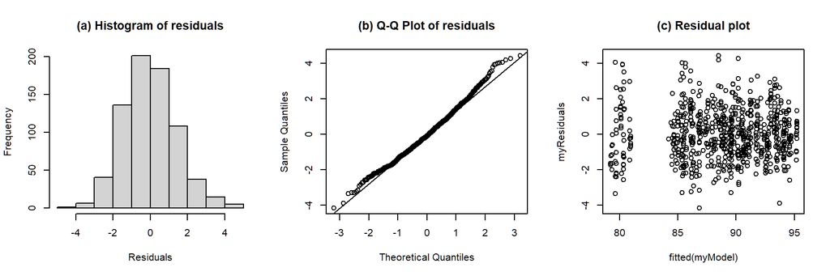

```
## Formula:  h_f0 ~ acc_phon + ana_syls + foot_syls + wrd_end_syl + pn_new_word + (1 | speaker) + (1 | nuc_pre_text) + (1 | str_syl)
##
## Linear mixed model fit by REML. t-tests use Satterthwaite's method [
## lmerModLmerTest]
## Formula: h_f0_equation
##    Data: pn_h_f0.trimmed
## Control:
## lmerControl(optimizer = optimizer, calc.derivs = FALSE, optCtrl = list(method = "nlminb",
##     starttests = FALSE, kkt = FALSE))
##
## REML criterion at convergence: 2697.3
##
## Scaled residuals:
##      Min       1Q   Median       3Q      Max
## -2.89574 -0.69423 -0.07852  0.60037  3.09230
##
## Random effects:
##  Groups       Name        Variance Std.Dev.
##  nuc_pre_text (Intercept)  1.0710  1.035
##  speaker      (Intercept) 17.2112  4.149
##  str_syl      (Intercept)  0.2916  0.540
##  Residual                  2.0552  1.434
## Number of obs: 733, groups:  nuc_pre_text, 12; speaker, 11; str_syl, 8
##
## Fixed effects:
##                 Estimate Std. Error       df t value Pr(>|t|)
## (Intercept)      88.1013     1.7107   8.6797  51.499 4.26e-12 ***
## acc_phon>H*       0.1807     0.2310 702.9923   0.782    0.434
## acc_phonH*        0.1506     0.1824 706.2151   0.826    0.409
## ana_syls1         0.4207     1.2399   3.2005   0.339    0.755
## ana_syls2        -0.1421     1.7832   2.4949  -0.080    0.942
## ana_syls3        -0.7910     1.7844   2.5008  -0.443    0.693
## foot_syls2        0.4565     1.2641   1.8631   0.361    0.755
## foot_syls3        0.6405     1.3780   1.7504   0.465    0.693
## foot_syls4        0.3890     1.5461   2.3666   0.252    0.822
## wrd_end_syl2      1.1454     0.8829   4.7997   1.297    0.253
## wrd_end_syl3     -0.3600     1.0693   8.2828  -0.337    0.745
## pn_new_wordTRUE  -0.4282     1.3162   3.3789  -0.325    0.764
## ---
## Signif. codes:  0 '***' 0.001 '**' 0.01 '*' 0.05 '.' 0.1 ' ' 1
```

[output cut: 40 more lines]

```
## Degrees of freedom method: Satterthwaite
##
##             Eliminated Sum Sq Mean Sq NumDF  DenDF F value    Pr(>F)
## acc_phon             1  2.096  1.0482     2 705.67  0.5076 0.6021829
## pn_new_word          2  2.346  2.3460     1   2.78  1.1375 0.3698098
## wrd_end_syl          3  6.976  3.4879     2  56.54  1.6896 0.1937883
## ana_syls             0 32.748 10.9160     3 264.98  5.2478 0.0015611 **
## foot_syls            0 39.333 13.1109     3 142.69  6.3030 0.0004795 ***
## ---
## Signif. codes:  0 '***' 0.001 '**' 0.01 '*' 0.05 '.' 0.1 ' ' 1
##
## Model found:
## h_f0 ~ ana_syls + foot_syls + (1 | speaker) + (1 | str_syl)
##
## isSingular(my_model, tol = 1e-05 ) --> FALSE
```

Anova of model: h_f0 ~ acc_phon + ana_syls + foot_syls + wrd_end_syl + pn_new_word + (1 | speaker) + (1 | nuc_pre_text) + (1 | str_syl)

| term | sumsq | meansq | NumDF | DenDF | F value | p.value | signif. |
| --- | --- | --- | --- | --- | --- | --- | --- |
| acc_phon | 2.013 | 1.006 | 2 | 704.002 | 0.490 | 0.61307438 |  |
| ana_syls | 12.706 | 4.235 | 3 | 2.874 | 2.061 | 0.28966229 |  |
| foot_syls | 0.496 | 0.165 | 3 | 2.000 | 0.081 | 0.96462287 |  |
| wrd_end_syl | 16.075 | 8.038 | 2 | 8.975 | 3.911 | 0.06005705 |  |
| pn_new_word | 0.218 | 0.218 | 1 | 3.379 | 0.106 | 0.76405223 |  |

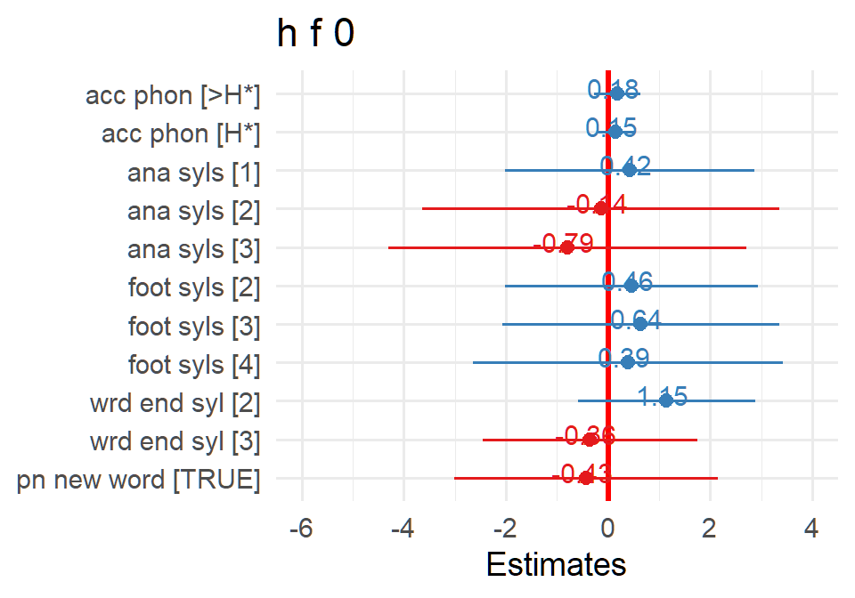

Conditional and marginal R<sup>2</sup> of model

| R2_conditional | R2_marginal |
| --- | --- |
| 0.89 | 0.02 |

$acc_phon

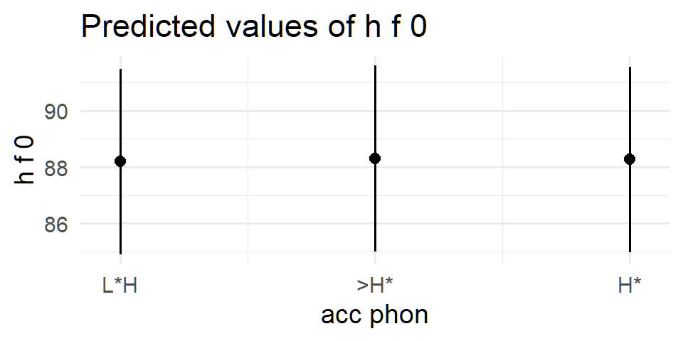

$ana_syls

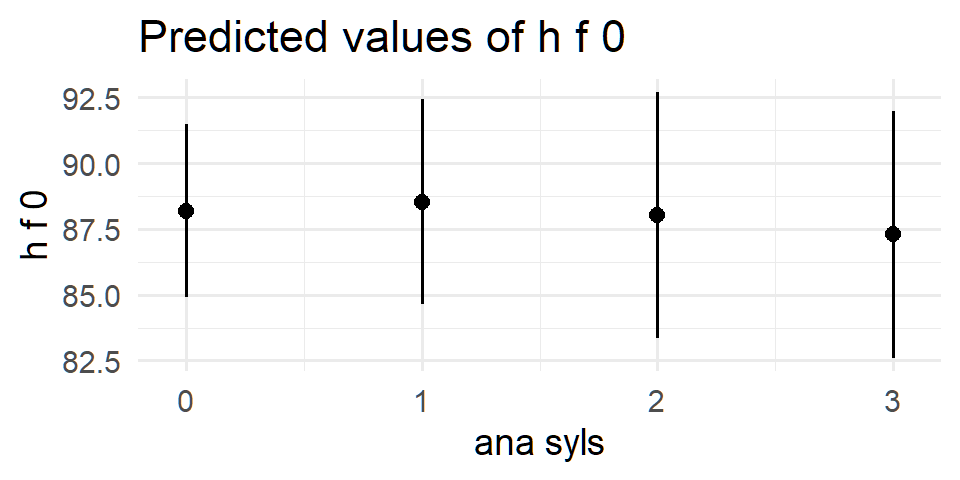

$foot_syls

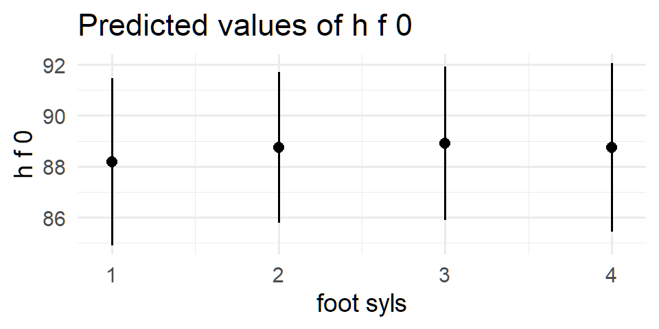

$wrd_end_syl

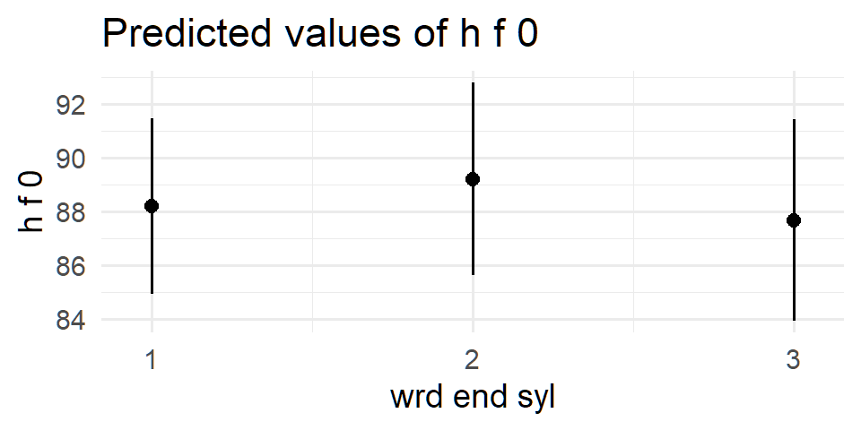

$pn_new_word

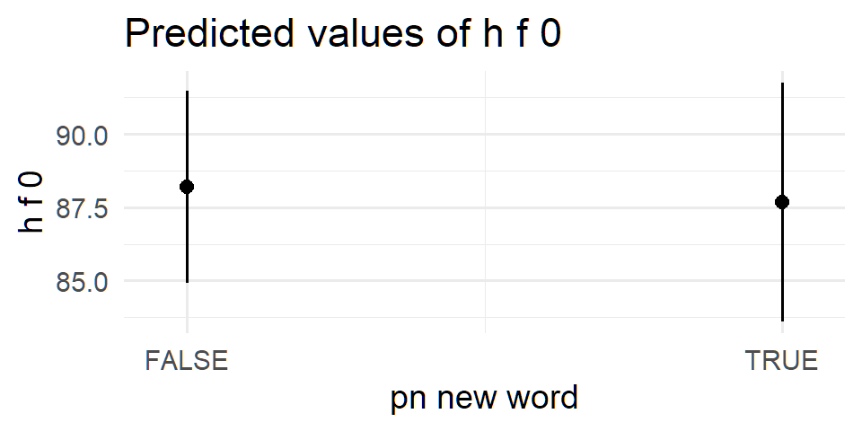

summary of model: h_f0 ~ acc_phon + ana_syls + foot_syls + wrd_end_syl + pn_new_word + (1 | speaker) + (1 | nuc_pre_text) + (1 | str_syl)

[output not shown]

b0 for h_f0 ~ acc_phon + ana_syls + foot_syls + wrd_end_syl + pn_new_word + (1 | speaker) + (1 | nuc_pre_text) + (1 | str_syl)

| intercept | estimate | conf.low | conf.high | std.error | t.value | df | p.value |
| --- | --- | --- | --- | --- | --- | --- | --- |
| acc_phonL*H | 88.1 | 84.2 | 92 | 1.711 | 51.499 | 8.68 | 4.3e-12 |
| acc_phon>H* | 88.3 | 84.4 | 92.2 | 1.722 | 51.280 | 8.91 | 2.6e-12 |
| acc_phonH* | 88.3 | 84.4 | 92.1 | 1.711 | 51.575 | 8.68 | 4.2e-12 |
| ana_syls0 | 88.1 | 84.2 | 92 | 1.711 | 51.499 | 8.68 | 4.3e-12 |
| ana_syls1 | 88.5 | 83.4 | 93.6 | 2.048 | 43.233 | 5.64 | 2.5e-08 |
| ana_syls2 | 88 | 81.2 | 94.7 | 2.470 | 35.609 | 4.13 | 2.7e-06 |
| ana_syls3 | 87.3 | 80.5 | 94.1 | 2.471 | 35.338 | 4.14 | 2.7e-06 |
| foot_syls1 | 88.1 | 84.2 | 92 | 1.711 | 51.499 | 8.68 | 4.3e-12 |
| foot_syls2 | 88.6 | 85.3 | 91.8 | 1.517 | 58.387 | 13.53 | 1.2e-17 |
| foot_syls3 | 88.7 | 85.3 | 92.2 | 1.567 | 56.636 | 12.00 | 6.1e-16 |
| foot_syls4 | 88.5 | 84.8 | 92.2 | 1.712 | 51.688 | 12.70 | 3.8e-16 |
| wrd_end_syl1 | 88.1 | 84.2 | 92 | 1.711 | 51.499 | 8.68 | 4.3e-12 |
| wrd_end_syl2 | 89.2 | 84.8 | 93.7 | 1.886 | 47.331 | 7.06 | 4.3e-10 |
| wrd_end_syl3 | 87.7 | 83.1 | 92.3 | 1.964 | 44.671 | 7.37 | 3.0e-10 |

b1 for h_f0 ~ acc_phon + ana_syls + foot_syls + wrd_end_syl + pn_new_word + (1 | speaker) + (1 | nuc_pre_text) + (1 | str_syl)

| intercept | slope | estimate | conf.low | conf.high | std.error | t.value | df | p.value |
| --- | --- | --- | --- | --- | --- | --- | --- | --- |
| acc_phonL*H | acc_phon>H* | 0.181 | -0.273 | 0.634 | 0.231 | 0.782 | 702.99 | 0.434 |
| acc_phonL*H | acc_phonH* | 0.151 | -0.208 | 0.509 | 0.182 | 0.826 | 706.22 | 0.409 |
| acc_phon>H* | acc_phonH* | -0.03 | -0.509 | 0.449 | 0.244 | -0.123 | 701.32 | 0.902 |
| ana_syls0 | ana_syls1 | 0.421 | -3.389 | 4.23 | 1.240 | 0.339 | 3.20 | 0.755 |
| ana_syls0 | ana_syls2 | -0.142 | -6.526 | 6.242 | 1.783 | -0.080 | 2.49 | 0.942 |
| ana_syls0 | ana_syls3 | -0.791 | -7.168 | 5.586 | 1.784 | -0.443 | 2.50 | 0.693 |
| ana_syls1 | ana_syls2 | -0.563 | -6.275 | 5.149 | 1.308 | -0.430 | 1.97 | 0.71 |
| ana_syls1 | ana_syls3 | -1.212 | -6.917 | 4.494 | 1.310 | -0.925 | 1.97 | 0.454 |
| ana_syls2 | ana_syls3 | -0.649 | -1.186 | -0.112 | 0.274 | -2.371 | 701.14 | 0.018 |
| foot_syls1 | foot_syls2 | 0.456 | -5.384 | 6.297 | 1.264 | 0.361 | 1.86 | 0.755 |
| foot_syls1 | foot_syls3 | 0.641 | -6.177 | 7.458 | 1.378 | 0.465 | 1.75 | 0.693 |
| foot_syls1 | foot_syls4 | 0.389 | -5.367 | 6.145 | 1.546 | 0.252 | 2.37 | 0.822 |
| foot_syls2 | foot_syls3 | 0.184 | -4.231 | 4.599 | 1.138 | 0.162 | 2.25 | 0.885 |
| foot_syls2 | foot_syls4 | -0.067 | -4.207 | 4.072 | 1.307 | -0.052 | 3.03 | 0.962 |
| foot_syls3 | foot_syls4 | -0.251 | -4.514 | 4.011 | 1.131 | -0.222 | 2.33 | 0.842 |
| wrd_end_syl1 | wrd_end_syl2 | 1.145 | -1.153 | 3.444 | 0.883 | 1.297 | 4.80 | 0.253 |
| wrd_end_syl1 | wrd_end_syl3 | -0.36 | -2.811 | 2.091 | 1.069 | -0.337 | 8.28 | 0.745 |
| wrd_end_syl2 | wrd_end_syl3 | -1.505 | -2.716 | -0.295 | 0.606 | -2.482 | 68.29 | 0.016 |
| intercept | pn_new_wordTRUE | -0.428 | -4.363 | 3.507 | 1.316 | -0.325 | 3.38 | 0.764 |

## Truncation and Compression Effects

Based on results from tonal target analysis, it looks there is an element of truncation in LH contours as a function of foot size, alongside a degree of rightward drift in L targets as foot size increases. However, superficially, it looks like the slope is stable.

As with nuclear data, I am retaining the overall model structure as much as possible BUT will discard all but foot_syls for analysis.

### LH Excursion

- first run, step() suggests: `f0_exc ~ foot_syls + ana_syls + (1 | speaker) + (1 | str_syl)`
- model needs trimming (|sd| residuals > 2.5)

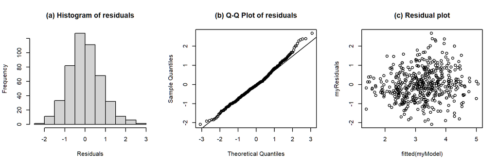

```
## Formula:  f0_exc ~ foot_syls + ana_syls + pn_new_word + wrd_end_syl + gender + (1 | speaker) + (1 | ana_text) + (1 | foot_dur) + (1 | str_syl)
##
## Linear mixed model fit by REML. t-tests use Satterthwaite's method [
## lmerModLmerTest]
## Formula: f0_exc_equation
##    Data: pn_f0_exc.trimmed
## Control:
## lmerControl(optimizer = optimizer, calc.derivs = FALSE, optCtrl = list(method = "nlminb",
##     starttests = FALSE, kkt = FALSE))
##
## REML criterion at convergence: 1301
##
## Scaled residuals:
##      Min       1Q   Median       3Q      Max
## -2.44804 -0.63188 -0.06173  0.56349  3.14811
##
## Random effects:
##  Groups   Name        Variance Std.Dev.
##  foot_dur (Intercept) 0.07081  0.2661
##  speaker  (Intercept) 0.16098  0.4012
##  str_syl  (Intercept) 0.32500  0.5701
##  ana_text (Intercept) 0.45362  0.6735
##  Residual             0.71987  0.8485
## Number of obs: 483, groups:
## foot_dur, 297; speaker, 11; str_syl, 8; ana_text, 7
##
## Fixed effects:
##                  Estimate Std. Error        df t value Pr(>|t|)
## (Intercept)       2.23112    0.79424   1.23682   2.809   0.1776
## foot_syls2        0.53958    0.25156 224.79202   2.145   0.0330 *
## foot_syls3        0.79318    0.24191 231.06502   3.279   0.0012 **
## foot_syls4        0.51250    0.29284 134.30062   1.750   0.0824 .
## ana_syls1        -0.07657    1.16706   1.47454  -0.066   0.9555
## ana_syls2         1.41985    1.43647   1.16332   0.988   0.4845
## ana_syls3         0.98166    1.43698   1.16484   0.683   0.6048
## pn_new_wordTRUE  -0.98978    1.04087   1.95586  -0.951   0.4439
## wrd_end_syl2      0.22117    0.18412 218.35851   1.201   0.2310
## wrd_end_syl3      0.47249    0.38743  34.82135   1.220   0.2308
## genderM           0.52723    0.26224   9.27442   2.010   0.0743 .
## ---
```

[output cut: 40 more lines]

```
## Degrees of freedom method: Satterthwaite
##
##             Eliminated  Sum Sq Mean Sq NumDF  DenDF F value   Pr(>F)
## wrd_end_syl          1  0.9960  0.4980     2 126.32  0.6312 0.533622
## pn_new_word          2  0.7118  0.7118     1   4.37  0.9038 0.391291
## gender               3  3.1372  3.1372     1   9.21  3.9812 0.076412 .
## foot_syls            0 11.8241  3.9414     3 317.23  5.0037 0.002102 **
## ana_syls             0 25.4782  8.4927     3 416.30 10.7820 7.76e-07 ***
## ---
## Signif. codes:  0 '***' 0.001 '**' 0.01 '*' 0.05 '.' 0.1 ' ' 1
##
## Model found:
## f0_exc ~ foot_syls + ana_syls + (1 | speaker) + (1 | str_syl)
##
## isSingular(my_model, tol = 1e-05 ) --> FALSE
```

Anova of model: f0_exc ~ foot_syls + ana_syls + pn_new_word + wrd_end_syl + gender + (1 | speaker) + (1 | ana_text) + (1 | foot_dur) + (1 | str_syl)

| term | sumsq | meansq | NumDF | DenDF | F value | p.value | signif. |
| --- | --- | --- | --- | --- | --- | --- | --- |
| foot_syls | 9.183 | 3.061 | 3 | 225.343 | 4.252 | 0.006030348 | p<0.01 |
| ana_syls | 2.458 | 0.819 | 3 | 2.000 | 1.138 | 0.499221960 |  |
| pn_new_word | 0.651 | 0.651 | 1 | 1.956 | 0.904 | 0.443944441 |  |
| wrd_end_syl | 1.425 | 0.713 | 2 | 55.885 | 0.990 | 0.377963303 |  |
| gender | 2.910 | 2.910 | 1 | 9.274 | 4.042 | 0.074335659 |  |

Conditional and marginal R<sup>2</sup> of model

| R2_conditional | R2_marginal |
| --- | --- |
| 0.67 | 0.21 |

$foot_syls

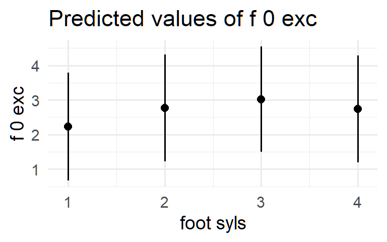

$ana_syls

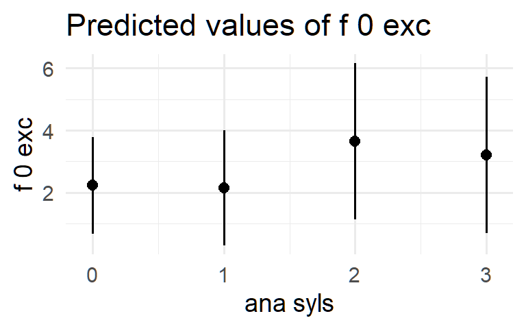

$pn_new_word

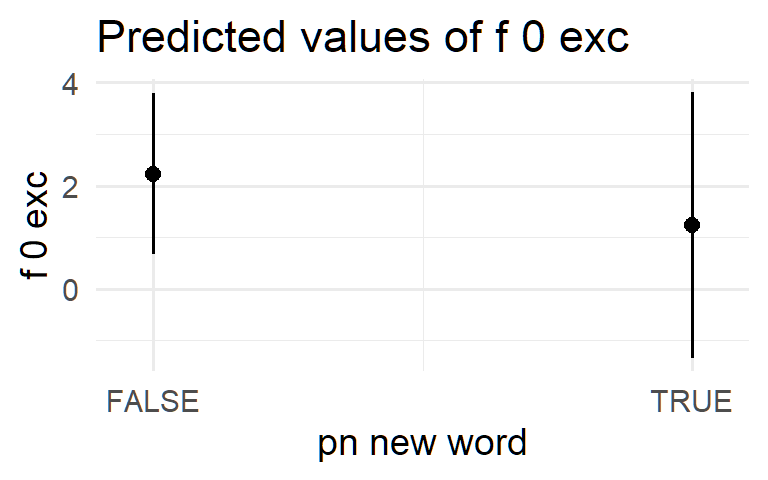

$wrd_end_syl

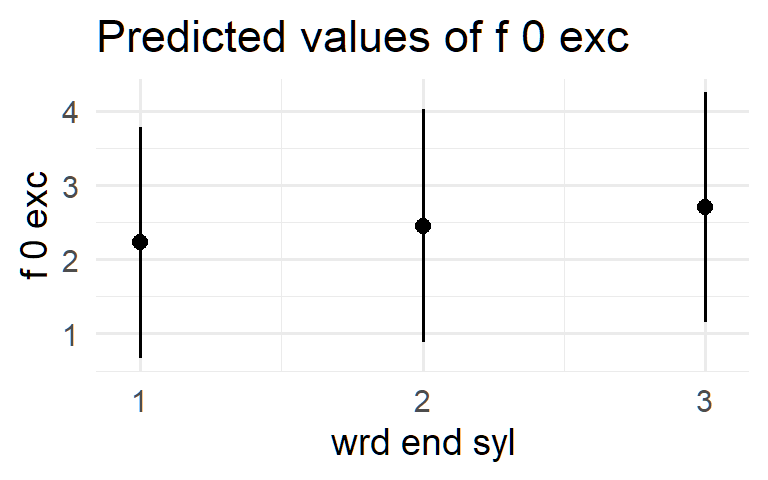

$gender

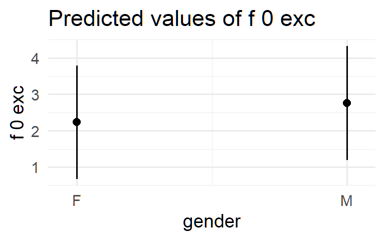

summary of model: f0_exc ~ foot_syls + ana_syls + pn_new_word + wrd_end_syl + gender + (1 | speaker) + (1 | ana_text) + (1 | foot_dur) + (1 | str_syl)

| term | estimate | conf.low | conf.high | std.error | t.value | df | p.value |
| --- | --- | --- | --- | --- | --- | --- | --- |
| (Intercept) | 2.231 | -4.26710798 | 8.7293544 | 0.794 | 2.809 | 1.24 | 0.1776 |
| foot_syls2 | 0.540 | 0.04386926 | 1.0352957 | 0.252 | 2.145 | 224.79 | 0.033 |
| foot_syls3 | 0.793 | 0.31654474 | 1.2698182 | 0.242 | 3.279 | 231.07 | 0.0012 |
| foot_syls4 | 0.512 | -0.06668525 | 1.0916810 | 0.293 | 1.750 | 134.30 | 0.0824 |
| ana_syls1 | -0.077 | -7.27072797 | 7.1175966 | 1.167 | -0.066 | 1.47 | 0.9555 |
| ana_syls2 | 1.420 | -11.76348760 | 14.6031837 | 1.436 | 0.988 | 1.16 | 0.4845 |
| ana_syls3 | 0.982 | -12.17272812 | 14.1360544 | 1.437 | 0.683 | 1.16 | 0.6048 |
| pn_new_wordTRUE | -0.990 | -5.56656281 | 3.5869955 | 1.041 | -0.951 | 1.96 | 0.4439 |
| wrd_end_syl2 | 0.221 | -0.14170369 | 0.5840482 | 0.184 | 1.201 | 218.36 | 0.231 |
| wrd_end_syl3 | 0.472 | -0.31417303 | 1.2591625 | 0.387 | 1.220 | 34.82 | 0.2308 |
| genderM | 0.527 | -0.06333448 | 1.1178031 | 0.262 | 2.010 | 9.27 | 0.0743 |

b0 for f0_exc ~ foot_syls + ana_syls + pn_new_word + wrd_end_syl + gender + (1 | speaker) + (1 | ana_text) + (1 | foot_dur) + (1 | str_syl)

| intercept | estimate | conf.low | conf.high | std.error | t.value | df | p.value |
| --- | --- | --- | --- | --- | --- | --- | --- |
| foot_syls1 | 2.231 | -4.267 | 8.729 | 0.794 | 2.809 | 1.24 | 0.178 |
| foot_syls2 | 2.771 | -4.192 | 9.734 | 0.788 | 3.517 | 1.19 | 0.145 |
| foot_syls3 | 3.024 | -4.383 | 10.4 | 0.779 | 3.883 | 1.14 | 0.136 |
| foot_syls4 | 2.744 | -4.101 | 9.588 | 0.788 | 3.484 | 1.20 | 0.145 |
| ana_syls0 | 2.231 | -4.267 | 8.729 | 0.794 | 2.809 | 1.24 | 0.178 |
| ana_syls1 | 2.155 | -1.279 | 5.589 | 0.941 | 2.289 | 2.43 | 0.127 |
| ana_syls2 | 3.651 | -4.411 | 11.7 | 1.280 | 2.852 | 1.45 | 0.148 |
| ana_syls3 | 3.213 | -4.861 | 11.3 | 1.280 | 2.511 | 1.45 | 0.174 |
| wrd_end_syl1 | 2.231 | -4.267 | 8.729 | 0.794 | 2.809 | 1.24 | 0.178 |
| wrd_end_syl2 | 2.452 | -3.766 | 8.671 | 0.800 | 3.067 | 1.27 | 0.156 |
| wrd_end_syl3 | 2.704 | -4.099 | 9.507 | 0.792 | 3.414 | 1.20 | 0.147 |

b1 for f0_exc ~ foot_syls + ana_syls + pn_new_word + wrd_end_syl + gender + (1 | speaker) + (1 | ana_text) + (1 | foot_dur) + (1 | str_syl)

| intercept | slope | estimate | conf.low | conf.high | std.error | t.value | df | p.value |
| --- | --- | --- | --- | --- | --- | --- | --- | --- |
| foot_syls1 | foot_syls2 | 0.54 | 0.044 | 1.035 | 0.252 | 2.145 | 224.79 | 0.033 |
| foot_syls1 | foot_syls3 | 0.793 | 0.317 | 1.27 | 0.242 | 3.279 | 231.07 | 0.001 |
| foot_syls1 | foot_syls4 | 0.512 | -0.067 | 1.092 | 0.293 | 1.750 | 134.30 | 0.082 |
| foot_syls2 | foot_syls3 | 0.254 | -0.177 | 0.684 | 0.219 | 1.158 | 314.10 | 0.248 |
| foot_syls2 | foot_syls4 | -0.027 | -0.57 | 0.516 | 0.275 | -0.098 | 171.15 | 0.922 |
| foot_syls3 | foot_syls4 | -0.281 | -0.632 | 0.071 | 0.179 | -1.571 | 332.88 | 0.117 |
| ana_syls0 | ana_syls1 | -0.077 | -7.271 | 7.118 | 1.167 | -0.066 | 1.47 | 0.955 |
| ana_syls0 | ana_syls2 | 1.42 | -11.8 | 14.6 | 1.436 | 0.988 | 1.16 | 0.485 |
| ana_syls0 | ana_syls3 | 0.982 | -12.2 | 14.1 | 1.437 | 0.683 | 1.16 | 0.605 |
| ana_syls1 | ana_syls2 | 1.496 | -16 | 19 | 0.862 | 1.736 | 0.84 | 0.367 |
| ana_syls1 | ana_syls3 | 1.058 | -16.5 | 18.6 | 0.862 | 1.228 | 0.84 | 0.464 |
| ana_syls2 | ana_syls3 | -0.438 | -44.3 | 43.4 | 0.968 | -0.452 | 0.66 | 0.756 |
| wrd_end_syl1 | wrd_end_syl2 | 0.221 | -0.142 | 0.584 | 0.184 | 1.201 | 218.36 | 0.231 |
| wrd_end_syl1 | wrd_end_syl3 | 0.472 | -0.314 | 1.259 | 0.387 | 1.220 | 34.82 | 0.231 |
| wrd_end_syl2 | wrd_end_syl3 | 0.251 | -0.449 | 0.951 | 0.340 | 0.739 | 24.91 | 0.467 |
| intercept | pn_new_wordTRUE | -0.99 | -5.567 | 3.587 | 1.041 | -0.951 | 1.96 | 0.444 |
| intercept | genderM | 0.527 | -0.063 | 1.118 | 0.262 | 2.010 | 9.27 | 0.074 |

### LH Slope

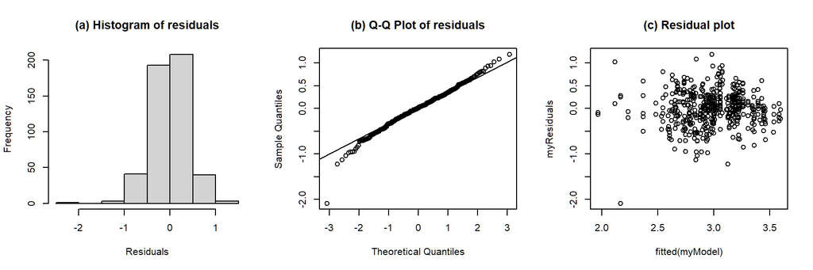

```
## Formula:  log_lh_slope ~ foot_syls + ana_syls + pn_new_word + wrd_end_syl + gender + (1 | speaker) + (1 | nuc_pre_text)
##
## Linear mixed model fit by REML. t-tests use Satterthwaite's method [
## lmerModLmerTest]
## Formula: lh_slope_equation
##    Data: pn_lh_slope.trimmed
## Control:
## lmerControl(optimizer = optimizer, calc.derivs = FALSE, optCtrl = list(method = "nlminb",
##     starttests = FALSE, kkt = FALSE))
##
## REML criterion at convergence: 527.7
##
## Scaled residuals:
##     Min      1Q  Median      3Q     Max
## -5.3513 -0.5653  0.0203  0.6017  3.0476
##
## Random effects:
##  Groups       Name        Variance Std.Dev.
##  nuc_pre_text (Intercept) 0.10402  0.3225
##  speaker      (Intercept) 0.01864  0.1365
##  Residual                 0.15160  0.3894
## Number of obs: 489, groups:  nuc_pre_text, 12; speaker, 11
##
## Fixed effects:
##                 Estimate Std. Error       df t value Pr(>|t|)
## (Intercept)      2.88675    0.33847  4.21454   8.529  0.00082 ***
## foot_syls2      -0.62125    0.38265  3.89940  -1.624  0.18162
## foot_syls3      -0.08083    0.42560  4.19111  -0.190  0.85823
## foot_syls4       0.10898    0.45740  4.98040   0.238  0.82118
## ana_syls1       -0.02964    0.32830  3.76521  -0.090  0.93267
## ana_syls2        0.11049    0.50748  3.90846   0.218  0.83853
## ana_syls3       -0.02594    0.50781  3.91640  -0.051  0.96176
## pn_new_wordTRUE  0.17919    0.34565  4.49720   0.518  0.62864
## wrd_end_syl2    -0.07994    0.25413 10.50336  -0.315  0.75925
## wrd_end_syl3    -0.13800    0.30353 17.15795  -0.455  0.65506
## genderM          0.27587    0.09284  9.33225   2.971  0.01507 *
## ---
## Signif. codes:  0 '***' 0.001 '**' 0.01 '*' 0.05 '.' 0.1 ' ' 1
##
## Correlation of Fixed Effects:
```

[output cut: 35 more lines]

```
## Degrees of freedom method: Satterthwaite
##
##             Eliminated  Sum Sq Mean Sq NumDF   DenDF F value  Pr(>F)
## wrd_end_syl          1 0.03334 0.01667     2 20.3453  0.1100 0.89640
## pn_new_word          2 0.04473 0.04473     1  5.3821  0.2952 0.60863
## ana_syls             3 0.70926 0.23642     3  8.8687  1.5589 0.26679
## foot_syls            4 2.05498 0.68499     3  6.3983  4.4768 0.05224 .
## gender               0 1.37273 1.37273     1  9.3500  8.9706 0.01446 *
## ---
## Signif. codes:  0 '***' 0.001 '**' 0.01 '*' 0.05 '.' 0.1 ' ' 1
##
## Model found:
## log_lh_slope ~ gender + (1 | speaker) + (1 | nuc_pre_text)
##
## isSingular(my_model, tol = 1e-05 ) --> FALSE
```

Anova of model: log_lh_slope ~ foot_syls + ana_syls + pn_new_word + wrd_end_syl + gender + (1 | speaker) + (1 | nuc_pre_text)

| term | sumsq | meansq | NumDF | DenDF | F value | p.value | signif. |
| --- | --- | --- | --- | --- | --- | --- | --- |
| foot_syls | 0.775 | 0.258 | 3 | 4.550 | 1.704 | 0.28991014 |  |
| ana_syls | 0.486 | 0.162 | 3 | 4.773 | 1.067 | 0.44429407 |  |
| pn_new_word | 0.041 | 0.041 | 1 | 4.497 | 0.269 | 0.62863864 |  |
| wrd_end_syl | 0.033 | 0.017 | 2 | 20.345 | 0.110 | 0.89639990 |  |
| gender | 1.338 | 1.338 | 1 | 9.332 | 8.829 | 0.01507073 | p<0.05 |

Conditional and marginal R<sup>2</sup> of model

| R2_conditional | R2_marginal |
| --- | --- |
| 0.57 | 0.22 |

$foot_syls

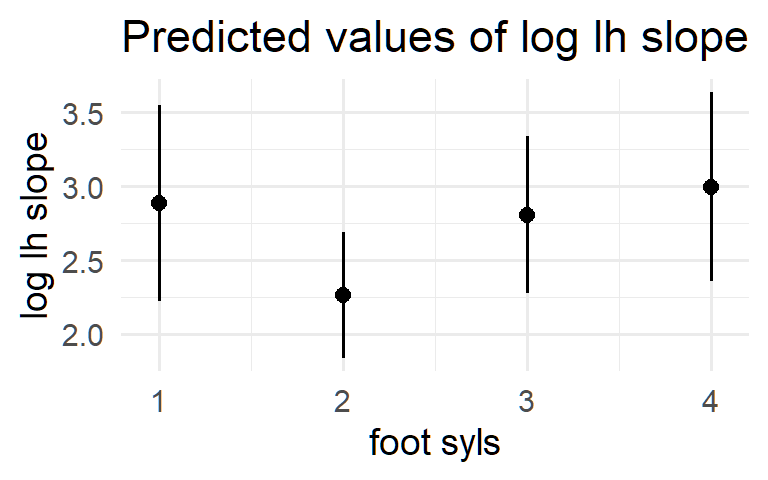

$ana_syls

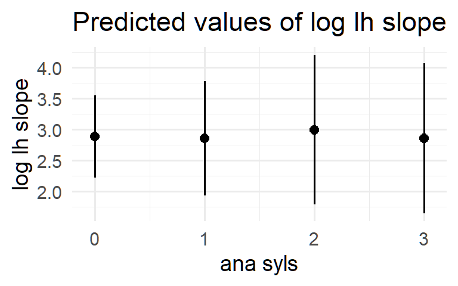

$pn_new_word

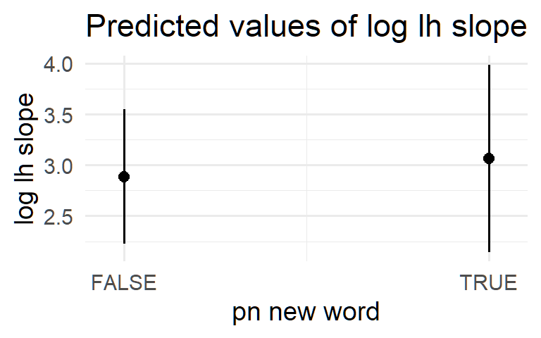

$wrd_end_syl

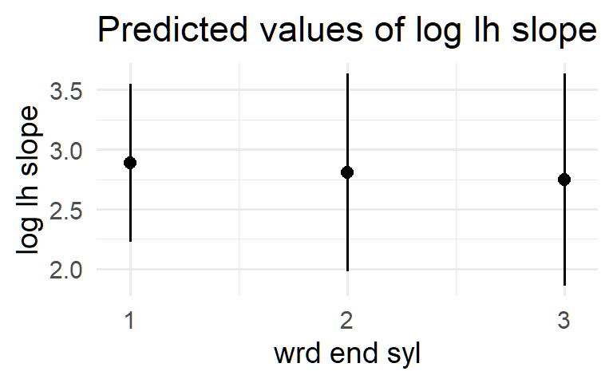

$gender

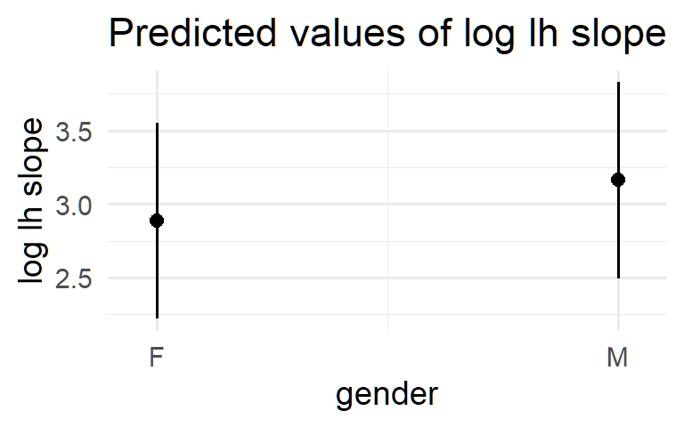

summary of model: log_lh_slope ~ foot_syls + ana_syls + pn_new_word + wrd_end_syl + gender + (1 | speaker) + (1 | nuc_pre_text)

| term | estimate | conf.low | conf.high | std.error | t.value | df | p.value |
| --- | --- | --- | --- | --- | --- | --- | --- |
| (Intercept) | 2.887 | 1.96556506 | 3.8079352 | 0.338 | 8.529 | 4.21 | 8e-04 |
| foot_syls2 | -0.621 | -1.69455092 | 0.4520417 | 0.383 | -1.624 | 3.90 | 0.1816 |
| foot_syls3 | -0.081 | -1.24153552 | 1.0798835 | 0.426 | -0.190 | 4.19 | 0.8582 |
| foot_syls4 | 0.109 | -1.06820332 | 1.2861568 | 0.457 | 0.238 | 4.98 | 0.8212 |
| ana_syls1 | -0.030 | -0.96398917 | 0.9047155 | 0.328 | -0.090 | 3.77 | 0.9327 |
| ana_syls2 | 0.110 | -1.31162074 | 1.5326065 | 0.507 | 0.218 | 3.91 | 0.8385 |
| ana_syls3 | -0.026 | -1.44779721 | 1.3959121 | 0.508 | -0.051 | 3.92 | 0.9618 |
| pn_new_wordTRUE | 0.179 | -0.74005716 | 1.0984446 | 0.346 | 0.518 | 4.50 | 0.6286 |
| wrd_end_syl2 | -0.080 | -0.64251384 | 0.4826316 | 0.254 | -0.315 | 10.50 | 0.7592 |
| wrd_end_syl3 | -0.138 | -0.77794813 | 0.5019497 | 0.304 | -0.455 | 17.16 | 0.6551 |
| genderM | 0.276 | 0.06697864 | 0.4847656 | 0.093 | 2.971 | 9.33 | 0.0151 |

b0 for log_lh_slope ~ foot_syls + ana_syls + pn_new_word + wrd_end_syl + gender + (1 | speaker) + (1 | nuc_pre_text)

| intercept | estimate | conf.low | conf.high | std.error | t.value | df | p.value |
| --- | --- | --- | --- | --- | --- | --- | --- |
| foot_syls1 | 2.887 | 1.966 | 3.808 | 0.338 | 8.529 | 4.21 | 8.2e-04 |
| foot_syls2 | 2.265 | 1.736 | 2.795 | 0.217 | 10.446 | 6.07 | 4.2e-05 |
| foot_syls3 | 2.806 | 2.11 | 3.501 | 0.271 | 10.348 | 5.04 | 1.4e-04 |
| foot_syls4 | 2.996 | 2.239 | 3.753 | 0.327 | 9.164 | 7.80 | 1.9e-05 |
| ana_syls0 | 2.887 | 1.966 | 3.808 | 0.338 | 8.529 | 4.21 | 8.2e-04 |
| ana_syls1 | 2.857 | 1.547 | 4.168 | 0.472 | 6.057 | 3.99 | 0.004 |
| ana_syls2 | 2.997 | 1.309 | 4.685 | 0.617 | 4.856 | 4.16 | 0.008 |
| ana_syls3 | 2.861 | 1.173 | 4.549 | 0.617 | 4.633 | 4.17 | 0.009 |
| wrd_end_syl1 | 2.887 | 1.966 | 3.808 | 0.338 | 8.529 | 4.21 | 8.2e-04 |
| wrd_end_syl2 | 2.807 | 1.754 | 3.86 | 0.422 | 6.647 | 5.57 | 7.6e-04 |
| wrd_end_syl3 | 2.749 | 1.674 | 3.824 | 0.453 | 6.073 | 6.85 | 5.5e-04 |

b1 for log_lh_slope ~ foot_syls + ana_syls + pn_new_word + wrd_end_syl + gender + (1 | speaker) + (1 | nuc_pre_text)

| intercept | slope | estimate | conf.low | conf.high | std.error | t.value | df | p.value |
| --- | --- | --- | --- | --- | --- | --- | --- | --- |
| foot_syls1 | foot_syls2 | -0.621 | -1.695 | 0.452 | 0.383 | -1.624 | 3.90 | 0.182 |
| foot_syls1 | foot_syls3 | -0.081 | -1.242 | 1.08 | 0.426 | -0.190 | 4.19 | 0.858 |
| foot_syls1 | foot_syls4 | 0.109 | -1.068 | 1.286 | 0.457 | 0.238 | 4.98 | 0.821 |
| foot_syls2 | foot_syls3 | 0.54 | -0.34 | 1.421 | 0.340 | 1.591 | 4.87 | 0.174 |
| foot_syls2 | foot_syls4 | 0.73 | -0.192 | 1.653 | 0.380 | 1.922 | 6.21 | 0.101 |
| foot_syls3 | foot_syls4 | 0.19 | -0.686 | 1.066 | 0.331 | 0.573 | 4.57 | 0.594 |
| ana_syls0 | ana_syls1 | -0.03 | -0.964 | 0.905 | 0.328 | -0.090 | 3.77 | 0.933 |
| ana_syls0 | ana_syls2 | 0.11 | -1.312 | 1.533 | 0.507 | 0.218 | 3.91 | 0.839 |
| ana_syls0 | ana_syls3 | -0.026 | -1.448 | 1.396 | 0.508 | -0.051 | 3.92 | 0.962 |
| ana_syls1 | ana_syls2 | 0.14 | -0.933 | 1.213 | 0.387 | 0.362 | 4.01 | 0.735 |
| ana_syls1 | ana_syls3 | 0.004 | -1.069 | 1.076 | 0.387 | 0.010 | 4.03 | 0.993 |
| ana_syls2 | ana_syls3 | -0.136 | -0.287 | 0.014 | 0.077 | -1.776 | 463.43 | 0.076 |
| wrd_end_syl1 | wrd_end_syl2 | -0.08 | -0.643 | 0.483 | 0.254 | -0.315 | 10.50 | 0.759 |
| wrd_end_syl1 | wrd_end_syl3 | -0.138 | -0.778 | 0.502 | 0.304 | -0.455 | 17.16 | 0.655 |
| wrd_end_syl2 | wrd_end_syl3 | -0.058 | -0.391 | 0.275 | 0.168 | -0.345 | 116.90 | 0.731 |
| intercept | pn_new_wordTRUE | 0.179 | -0.74 | 1.098 | 0.346 | 0.518 | 4.50 | 0.629 |
| intercept | genderM | 0.276 | 0.067 | 0.485 | 0.093 | 2.971 | 9.33 | 0.015 |